# Olympics game Data Analysis

# Problem Statement

The Olympic Games are one of the largest and most prestigious sporting events in the world, bringing together athletes from various nations to compete in different sports. Analyzing historical Olympic data can provide valuable insights into trends, performance patterns, and key factors contributing to success.

This project aims to perform Exploratory Data Analysis (EDA) on Olympic datasets using Python (pandas, seaborn, matplotlib) to uncover patterns related to athlete participation, medal distribution, country-wise performance, gender representation, and sport-wise trends. The insights gained can help sports analysts, policymakers, and researchers understand historical trends and make informed decisions for future events.

# Summary of the Dataset

The dataset consists of historical Olympic data, including details about athletes, sports, events, countries, medals won, and participation across different Olympic editions. It includes attributes such as: ID – Unique identifier for each athlete Name – Name of the athlete Sex – Gender of the athlete (Male/Female) Age – Age of the athlete during the event Height – Height of the athlete (in cm) Weight – Weight of the athlete (in kg) Team – Country or team the athlete represents NOC – National Olympic Committee (Country Code) Games – Year and season of the Olympic Games Sport – Sport in which the athlete competed Event – Specific event within a sport Medal – Type of medal won (Gold, Silver, Bronze, or None) The dataset spans multiple Olympic events, allowing us to analyze trends such as the evolution of participation, dominant countries, gender representation over time, and correlations between athlete characteristics and performance.

# Importing useful libraries

```python
import pandas as pd
import numpy as np
import matplotlib.pyplot as plt
import seaborn as sns
```

# import dataset

```python
import pandas as pd

# Define the file path
file_path = r"D:\User\Saru\dataset_olympics.csv"

# Load the dataset
df = pd.read_csv(file_path)

# Display the first five rows
df.head()
```

|  | ID | Name | Sex | Age | Height | Weight | Team | NOC | Games | Year | Season | City | Sport | Event | Medal |
| --- | --- | --- | --- | --- | --- | --- | --- | --- | --- | --- | --- | --- | --- | --- | --- |
| 0 | 1 | A Dijiang | M | 24.0 | 180.0 | 80.0 | China | CHN | 1992 Summer | 1992 | Summer | Barcelona | Basketball | Basketball Men's Basketball | NaN |
| 1 | 2 | A Lamusi | M | 23.0 | 170.0 | 60.0 | China | CHN | 2012 Summer | 2012 | Summer | London | Judo | Judo Men's Extra-Lightweight | NaN |
| 2 | 3 | Gunnar Nielsen Aaby | M | 24.0 | NaN | NaN | Denmark | DEN | 1920 Summer | 1920 | Summer | Antwerpen | Football | Football Men's Football | NaN |
| 3 | 4 | Edgar Lindenau Aabye | M | 34.0 | NaN | NaN | Denmark/Sweden | DEN | 1900 Summer | 1900 | Summer | Paris | Tug-Of-War | Tug-Of-War Men's Tug-Of-War | Gold |
| 4 | 5 | Christine Jacoba Aaftink | F | 21.0 | 185.0 | 82.0 | Netherlands | NED | 1988 Winter | 1988 | Winter | Calgary | Speed Skating | Speed Skating Women's 500 metres | NaN |

```python
df.info()
```

```
<class 'pandas.core.frame.DataFrame'>
RangeIndex: 70000 entries, 0 to 69999
Data columns (total 15 columns):
 #   Column  Non-Null Count  Dtype
---  ------  --------------  -----
 0   ID      70000 non-null  int64
 1   Name    70000 non-null  object
 2   Sex     70000 non-null  object
 3   Age     67268 non-null  float64
 4   Height  53746 non-null  float64
 5   Weight  52899 non-null  float64
 6   Team    70000 non-null  object
 7   NOC     70000 non-null  object
 8   Games   70000 non-null  object
 9   Year    70000 non-null  int64
 10  Season  70000 non-null  object
 11  City    70000 non-null  object
 12  Sport   70000 non-null  object
 13  Event   70000 non-null  object
 14  Medal   9690 non-null   object
dtypes: float64(3), int64(2), object(10)
memory usage: 8.0+ MB
```

```python
df.describe(include =["object"])
```

|  | Name | Sex | Team | NOC | Games | Season | City | Sport | Event | Medal |
| --- | --- | --- | --- | --- | --- | --- | --- | --- | --- | --- |
| count | 70000 | 70000 | 70000 | 70000 | 70000 | 70000 | 70000 | 70000 | 70000 | 9690 |
| unique | 35556 | 2 | 827 | 226 | 51 | 2 | 42 | 65 | 744 | 3 |
| top | Oksana Aleksandrovna Chusovitina | M | United States | USA | 2016 Summer | Summer | London | Athletics | Football Men's Football | Gold |
| freq | 29 | 51877 | 4979 | 5216 | 3675 | 58467 | 6034 | 10629 | 1738 | 3292 |

# Checking for missing values

```python
df.isna().sum()
```

```
ID            0
Name          0
Sex           0
Age        2732
Height    16254
Weight    17101
Team          0
NOC           0
Games         0
Year          0
Season        0
City          0
Sport         0
Event         0
Medal     60310
dtype: int64
```

# Removing duplicates

```python
df.duplicated().sum()
```

```
383
```

```python
df.drop_duplicates(inplace = True)
df.duplicated().sum()
```

```
0
```

# Visualization makes it easy understand data

# Distribution by Gender

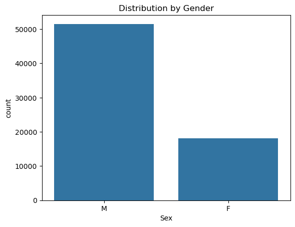

```python
sns.countplot(data = df, x = "Sex")
plt.title("Distribution by Gender")
plt.show()
```

# Age Distribution

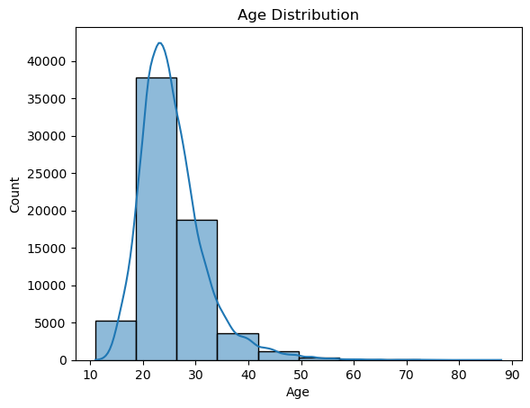

```python
sns.histplot( data = df, x = "Age", bins = 10, kde = True)
plt.title("Age Distribution")
plt.show()
```

# Height Distribution

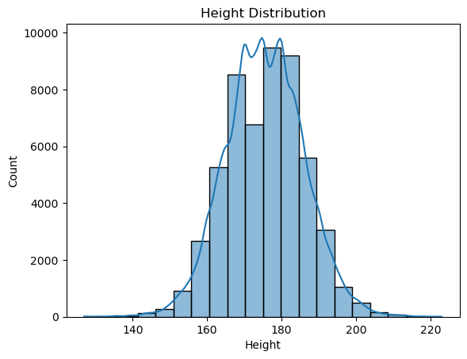

```python
sns.histplot( data = df, x = "Height", bins = 20, kde = True )
plt.title("Height Distribution")
plt.show()
```

# Weight Distribution

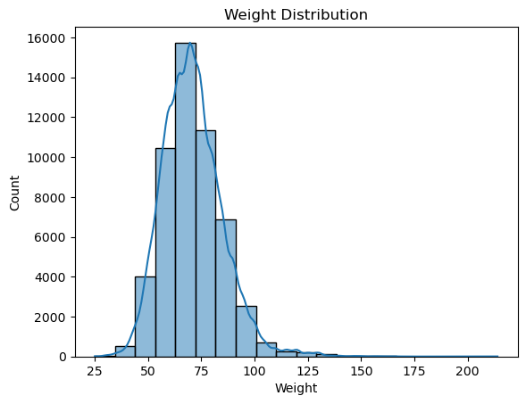

```python
sns.histplot( data = df, x = "Weight", bins = 20, kde = True)
plt.title("Weight Distribution")
plt.show()
```

# Number of participants per year

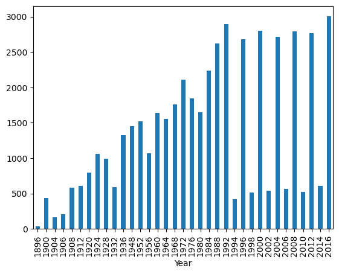

```python
year_participants_count = df.groupby("Year")["ID"].nunique()
year_participants_count.plot(kind = 'bar')
plt.show()
```

# Number of unique events per sport

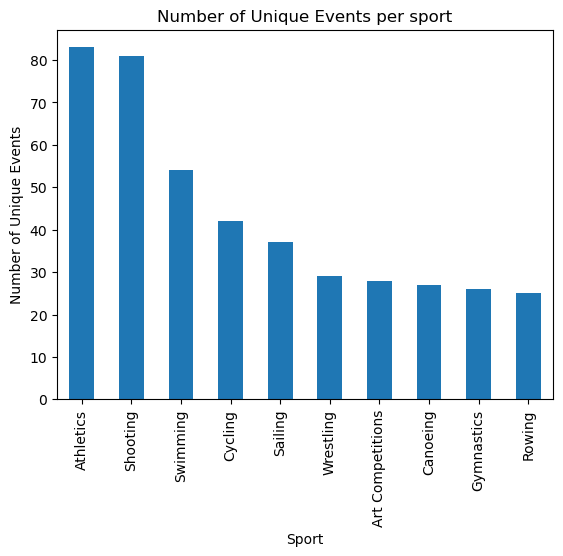

```python
country_event_count = df.groupby(["Sport"])["Event"].nunique().sort_values(ascending = False).iloc[:10]
country_event_count.plot(kind = 'bar')
plt.title("Number of Unique Events per sport")
plt.xlabel("Sport")
plt.ylabel("Number of Unique Events")
plt.show()
```

# Avg. age by country

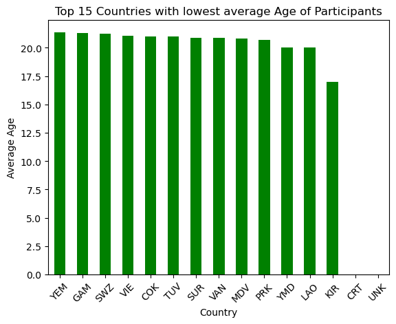

```python
avg_age_by_country = df.groupby("NOC")["Age"].mean().sort_values(ascending = False)
avg_age_by_country.tail(15).plot(kind = "bar",color = "green")
plt.title("Top 15 Countries with lowest average Age of Participants")
plt.xlabel("Country")
plt.ylabel("Average Age")
plt.xticks(rotation = 45)
plt.show()
```

# Distribution of Ages of Season

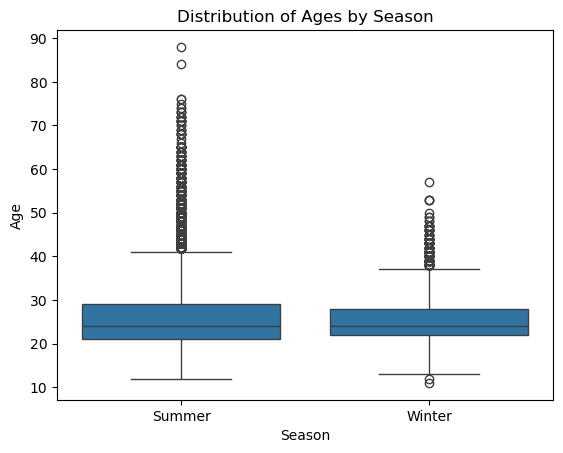

```python
sns.boxplot( data = df, x = "Season", y = "Age")
plt.title("Distribution of Ages by Season")
plt.xlabel("Season")
plt.ylabel("Age")
plt.show()
```

# Distribution of heights by medals

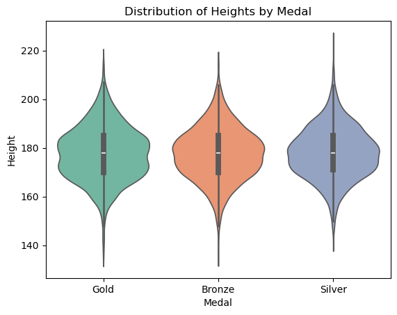

```python
sns.violinplot(data = df, x = "Medal", y = "Height", palette = "Set2")
plt.title("Distribution of Heights by Medal")
plt.xlabel("Medal")
plt.ylabel("Height")
plt.show()
```

# Relation between the Height and Weight of Athlete with respect to Medals.

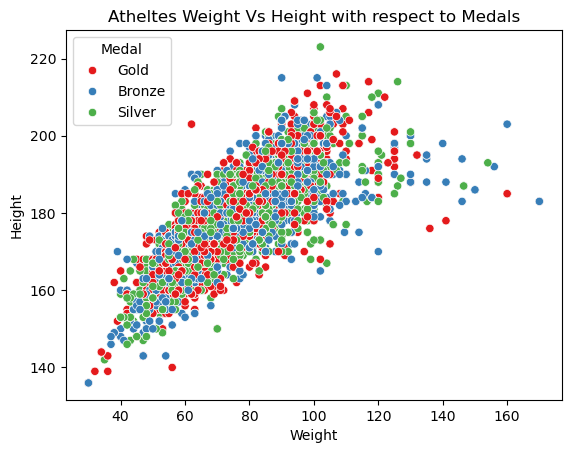

```python
sns.scatterplot(data = df , x = "Weight", y = "Height", hue = "Medal", palette="Set1")
plt.title("Atheltes Weight Vs Height with respect to Medals")
plt.xlabel("Weight")
plt.ylabel("Height")
plt.show()
```